# Trabajo 1 — Series de tiempo

**Mostrar/ocultar código**

```r
resultado_opt_ses3 <- optimizar(
  y = y3_est,
  metodo = "ses",
  rejilla = seq(0.02, 0.98, by = 0.1)
)

resultado_opt_ses3$rejilla
```

| alpha | MSE |
| --- | --- |
| 0.02 | 1342.068 |
| 0.12 | 1176.224 |
| 0.22 | 1219.582 |
| 0.32 | 1265.065 |
| 0.42 | 1292.915 |
| 0.52 | 1299.579 |
| 0.62 | 1288.306 |
| 0.72 | 1265.601 |
| 0.82 | 1238.225 |
| 0.92 | 1211.308 |

**Mostrar/ocultar código**

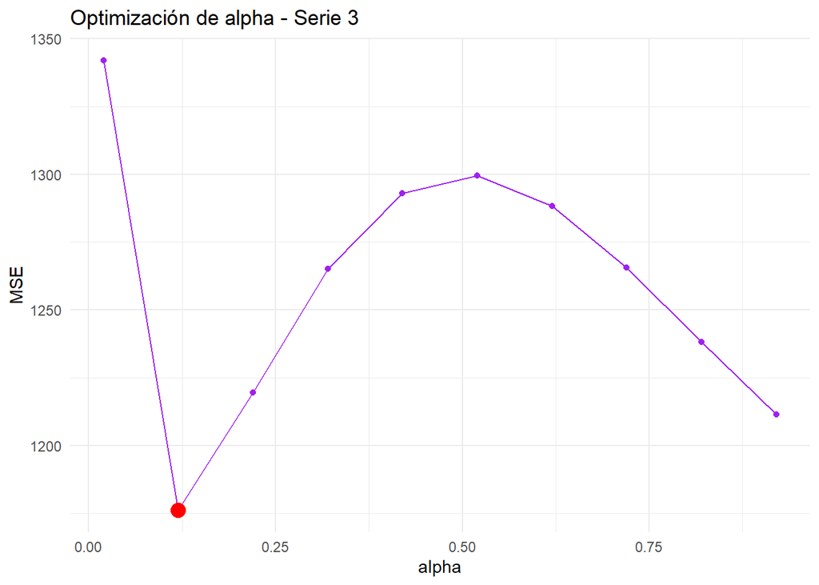

```r
grafico_opt_ses3 <- graficar_optimizacion(
  resultado = resultado_opt_ses3,
  parametro = "alpha",
  titulo = "Optimización de alpha - Serie 3"
)

grafico_opt_ses3
```

**Mostrar/ocultar código**

```r
modelo_ses3 <- ajustar_ses(
  y = y3_est,
  alpha = resultado_opt_ses3$optimo$alpha
)

pronosticos_ses3 <- modelo_ses3$pronosticar(h_3)

cat(
  "Horizonte de validación (h):", h_3, "\n",
  "Alpha óptimo:", resultado_opt_ses3$optimo$alpha, "\n",
  "Pronóstico constante:", round(pronosticos_ses3[1], 7), "\n"
)
```

```
Horizonte de validación (h): 7
 Alpha óptimo: 0.12
 Pronóstico constante: 418.204
```

El método SES, con un parámetro de suavización óptimo de $\alpha=0.12$, genera un pronóstico constante de 418.204 millones de pesos diarios para cada uno de los próximos siete días.

**Tendencia con ficticias de suma cero**

**Mostrar/ocultar código**

```r
modelo_tf3 <- ajustar_tendencia_estacional(y3_est, 7)
```

**Mostrar/ocultar código**

```r
pronosticos_tf3 <- modelo_tf3$pronosticar(h_3)

cat(
  "Horizonte de validación (h):", h_3, "\n",
  "Pronóstico Tendencia ficticia:", round(pronosticos_tf3[1:7], 7), "\n"
)
```

```
Horizonte de validación (h): 7
 Pronóstico Tendencia ficticia: 393.9604 405.0013 436.1104 476.6786 419.9422 382.3461 392.2808
```

El método produce pronósticos variables para los próximos siete días, que oscilan entre 382.3461 y 476.6786 millones de pesos diarios. A diferencia de los métodos que generan un pronóstico constante, este método permite obtener valores distintos para cada día del horizonte de validación.

**Prueba t de los Coeficientes**

Prueba de Hipótesis:

$$H_0: \beta_j=0$$

$$H_1: \beta_j \neq 0$$

Estadístico de prueba:
$$t = \frac{\hat{\beta}_j}{SE_{\text{robusto}}(\hat{\beta}_j)}$$
Distribución bajo $H_0$:

$$t \sim t_{n-3}$$

Región de rechazo:

$$|t|> t_{0.975, n-3}$$

**Mostrar/ocultar código**

```r
tabla_coef_tf3 <- modelo_tf3$parametros$coeficientes

tabla_coef_tf3$estimacion   <- round(tabla_coef_tf3$estimacion, 4)
tabla_coef_tf3$se_ordinario <- round(tabla_coef_tf3$se_ordinario, 4)
tabla_coef_tf3$se_robusto   <- round(tabla_coef_tf3$se_robusto, 4)
tabla_coef_tf3$t            <- round(tabla_coef_tf3$t, 4)
tabla_coef_tf3$valor_p      <- format.pval(tabla_coef_tf3$valor_p, digits = 4, eps = 0.0001)

tabla_coef_tf3
```

| coeficiente | estimacion | se_ordinario | se_robusto | t | valor_p |
| --- | --- | --- | --- | --- | --- |
| beta_0 | 386.7364 | 2.4559 | 4.4799 | 86.3265 | < 1e-04 |
| beta_1 | 0.1778 | 0.0271 | 0.0407 | 4.3670 | < 1e-04 |
| gamma_1 | -33.1982 | 2.9535 | 2.1275 | -15.6042 | < 1e-04 |
| gamma_2 | -23.4412 | 2.9535 | 2.3096 | -10.1496 | < 1e-04 |
| gamma_3 | -20.6947 | 3.0091 | 1.9048 | -10.8644 | < 1e-04 |
| gamma_4 | -9.8316 | 3.0087 | 2.1401 | -4.5940 | < 1e-04 |
| gamma_5 | 21.0997 | 3.0086 | 2.3276 | 9.0650 | < 1e-04 |
| gamma_6 | 61.4900 | 3.0087 | 1.9616 | 31.3468 | < 1e-04 |

El modelo Tendencia con Ficticias presenta una tendencia creciente en las ventas, con un aumento estimado de 0.1778 millones de pesos diarios. Además, las variables ficticias muestran diferencias significativas entre los días de la semana respecto al día de referencia. Las pruebas t, calculadas con errores estándar robustos a la autocorrelación mediante el núcleo de Bartlett, indican que todos los coeficientes son estadísticamente significativos, con valores p inferiores a 0.0001. Esto sugiere que tanto la tendencia como el día de la semana ayudan a explicar el comportamiento de las ventas.

**Revisión de los supuestos**

**Mostrar/ocultar código**

```r
residuos_tf3 <- modelo_tf3$parametros$residuos

diagnostico_tf3 <- validar_errores(
  e = residuos_tf3,
  m = NULL,
  p = 0
)
```

Correlograma

**Mostrar/ocultar código**

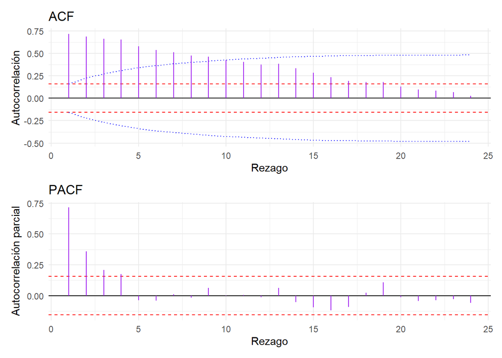

```r
diagnostico_tf3$correlograma$grafico
```

En el ACF se observan autocorrelacione significativas, lo que muestra que los residuos del modelo están fuertemente relacionados entre sí a lo largo del tiempo. Por su parte, el PACF presenta un pico alto en el primer rezago que confirma esta persistencia en los datos. En conjunto, esto significa que los errores no se comportan como ruido blanco, por lo que el modelo de tendencia con variable ficticia no ha logrado capturar toda la información.

Ljung Box

Prueba de Hipótesis

$$H_0:\rho_1=\rho_2=\cdots=\rho_{m}=0$$
$$H_1:\text{al menos una }\rho_h\neq0$$

Estadístico de Prueba

$$Q = T(T + 2) \sum_{h=1}^{m} \frac{{r}_h^2}{T - h}$$

Distribución

Región de Rechazo

**Mostrar/ocultar código**

```r
cat(
  "Estadístico de prueba:", round(
    diagnostico_tf3$ljung_box$estadistico, 4
  ), "\n",
  "Grados de libertad:", diagnostico_tf3$ljung_box$grados_libertad, "\n",
  "Valor crítico:", round(
    diagnostico_tf3$ljung_box$valor_critico, 4
  ), "\n",
  "Valor p:", round(
    diagnostico_tf3$ljung_box$valor_p, 4
  ), "\n"
)
```

```
Estadístico de prueba: 690.7941
 Grados de libertad: 24
 Valor crítico: 36.415
 Valor p: 0
```

En la prueba de Ljung-Box se observa un valor p cercano a cero. Por tanto, se rechaza la hipótesis nula de ausencia de autocorrelación en los errores. Esto indica que los errores del modelo de tendencia con variables ficticias presentan dependencia temporal, por lo que el modelo no captura toda la dinámica de las ventas diarias.

Jarque Bera

$$H_0:\text{los errores tienen distribución normal}$$
$$H_1:\text{los errores no tienen distribución normal}$$

Distribución Bajo $H_0$:

$$JB \sim \chi^2_{2}$$

Estadístico de Prueba

$$JB = \frac{T}{6} \left( A^2 + \frac{(K - 3)^2}{4} \right)$$

**Mostrar/ocultar código**

```r
cat(
  "Estadístico de prueba:", round(
    diagnostico_tf3$jarque_bera$estadistico, 4
  ), "\n",
  "Grados de libertad:", diagnostico_tf3$jarque_bera$grados_libertad, "\n",
  "Valor crítico:", round(
    diagnostico_tf3$jarque_bera$valor_critico, 4
  ), "\n",
  "Valor p:", format.pval(
    diagnostico_tf3$jarque_bera$valor_p,
    digits = 4
  ), "\n"
)
```

```
Estadístico de prueba: 8.8236
 Grados de libertad: 2
 Valor crítico: 5.9915
 Valor p: 0.01213
```

La prueba de Jarque-Bera presenta un valor p de 0.01213. Por tanto, se rechaza la hipótesis nula de normalidad, lo que indica que los errores del modelo de tendencia con variables ficticias no siguen una distribución normal.

Durbin Watson

$$H_0:\rho=0$$
$$H_1:\rho\neq0$$

Estadístico de Prueba:

$$DW=\frac{\sum_{t=2}^{T}(e_t-e_{t-1})^2} {\sum_{t=1}^{T}e_t^2}$$

**Mostrar/ocultar código**

```r
diagnostico_tf3$durbin_watson <-
  durbin_watson(modelo_tf3$parametros$residuos)

cat(
  "Estadístico de prueba:",
  round(diagnostico_tf3$durbin_watson$estadistico, 4), "\n",
  "d aprox:",
  round(diagnostico_tf3$durbin_watson$d_aprox, 4), "\n",
  "dL:",
  round(diagnostico_tf3$durbin_watson$dL, 4), "\n",
  "dU:",
  round(diagnostico_tf3$durbin_watson$dU, 4), "\n"
)
```

```
Estadístico de prueba: 0.5607
 d aprox: 0.5684
 dL: 1.6765
 dU: 1.7086
```

El valor de la prueba de Durbin-Watson (aproximadamente 0.56) se encuentra muy por debajo del límite inferior ($d_L = 1.6765$), lo que indica que existe una fuerte autocorrelación positiva en los errores del modelo. Esto significa que los residuos no son independientes entre sí y que el modelo de tendencia actual deja información importante sin explicar en el tiempo.

**Holt–Winters aditivo**

**Mostrar/ocultar código**

```r
# Alfa, Beta, Gamma optimos
rejilla_hw <- seq(0.1, 0.9, by = 0.1)

opt_holt_ad <- optimizar(
  y = y3_est,
  metodo = "hw",
  rejilla = rejilla_hw,
  s=7
)

opt_holt_ad$rejilla
```

| alpha | beta | gamma | MSE |
| --- | --- | --- | --- |
| 0.1 | 0.1 | 0.1 | 200.7306 |
| 0.2 | 0.1 | 0.1 | 121.9813 |
| 0.3 | 0.1 | 0.1 | 107.8887 |
| 0.4 | 0.1 | 0.1 | 107.1456 |
| 0.5 | 0.1 | 0.1 | 111.7065 |
| 0.6 | 0.1 | 0.1 | 119.7075 |
| 0.7 | 0.1 | 0.1 | 131.1495 |
| 0.8 | 0.1 | 0.1 | 147.4289 |
| 0.9 | 0.1 | 0.1 | 172.1567 |
| 0.1 | 0.2 | 0.1 | 170.3464 |

[output cut: 719 more lines]

**Mostrar/ocultar código**

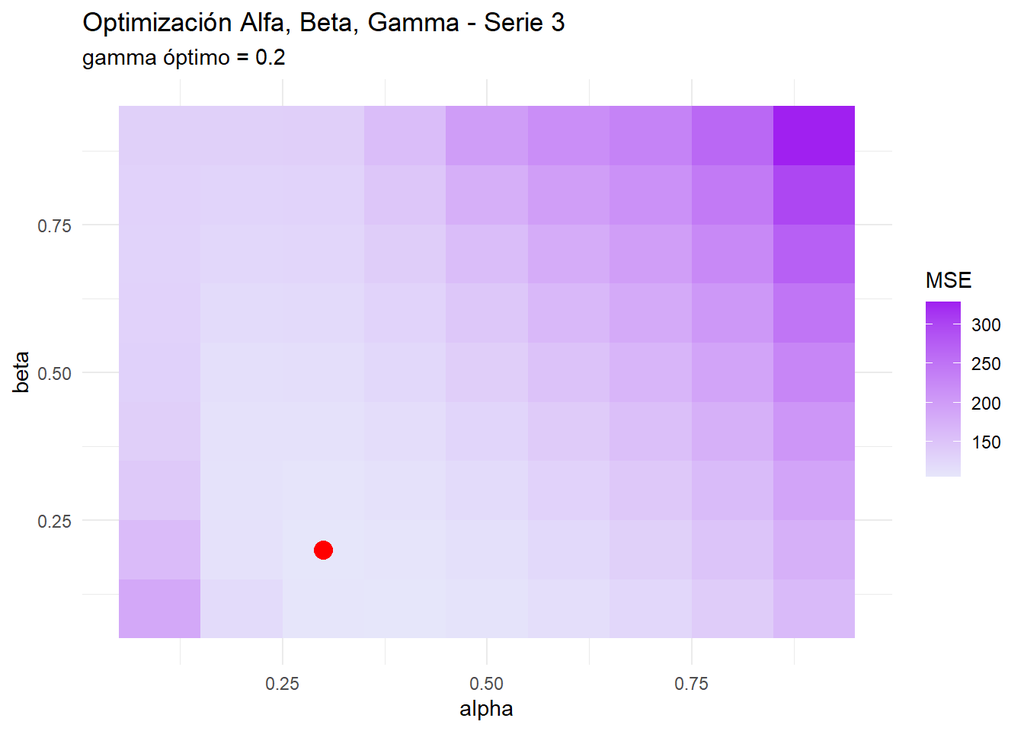

```r
# Graficar alfa, beta optimos
graficar_hw(opt_holt_ad, "Optimización Alfa, Beta, Gamma - Serie 3")
```

**Mostrar/ocultar código**

```r
# Ajustar el modelo
alpha_opt_ad <- opt_holt_ad$optimo$alpha
beta_opt_ad <- opt_holt_ad$optimo$beta
gamma_opt_ad <- opt_holt_ad$optimo$gamma
```

**Mostrar/ocultar código**

```r
modelo_holt_ad <- ajustar_hw(
  y3_est,
  s=7,
  alpha_opt_ad,
  beta_opt_ad,
  gamma_opt_ad
)
```

**Mostrar/ocultar código**

```r
# Pronosticos
pronosticos_hw_ad <- modelo_holt_ad$pronosticar(h_3)

cat(
  "Horizonte de validación (h):", h_3, "\n",
  "Pronósticos Holt Winters Aditivo:", round(pronosticos_hw_ad, 7), "\n"
)
```

```
Horizonte de validación (h): 7
 Pronósticos Holt Winters Aditivo: 412.9139 427.502 459.879 501.6981 447.1847 408.4918 422.1109
```

El método Holt–Winters aditivo, con un ciclo estacional de siete días, genera pronósticos para los próximos siete días entre 408.4918 y 501.6981 millones de pesos diarios. Las variaciones reflejan tanto la tendencia como los efectos estacionales semanales.

**Holt-Winters Multiplicativo**

**Mostrar/ocultar código**

```r
# Ajustar modelo
modelo_holt_mult <- ajustar_hw_mult(
  y3_est,
  s=7,
  alpha_opt_ad,
  beta_opt_ad,
  gamma_opt_ad
)
```

**Mostrar/ocultar código**

```r
# Pronosticos
pronosticos_hw_mult <- modelo_holt_mult$pronosticar(h_3)

cat(
  "Horizonte de validación (h):", h_3, "\n",
  "Pronósticos Holt Winters Multiplicativo:", round(pronosticos_hw_mult, 7), "\n"
)
```

```
Horizonte de validación (h): 7
 Pronósticos Holt Winters Multiplicativo: 412.3536 427.5115 462.2339 507.5826 449.181 407.1318 421.4457
```

El método Holt–Winters multiplicativo genera pronósticos para los próximos siete días entre 407.1318 y 507.5826 millones de pesos diarios. Este método incorpora la tendencia y los efectos estacionales semanales, suponiendo que las variaciones estacionales son proporcionales al nivel de las ventas.

**Tendencia Lineal (Contraste)**

**Mostrar/ocultar código**

```r
# Ajustar Tendencia lineal
modelo_tendencia3 <- ajustar_tendencia(
  y = y3_est,
  tipo = "lineal",
  corregir_sesgo = FALSE
)
```

**Mostrar/ocultar código**

```r
# Pronosticos
pronosticos_tendencia3 <- modelo_tendencia3$pronosticar(h_3)

cat(
  "Horizonte de validación (h):", h_3, "\n",
  "Pronósticos de tendencia lineal:",
  round(pronosticos_tendencia3, 4), "\n"
)
```

```
Horizonte de validación (h): 7
 Pronósticos de tendencia lineal: 414.9851 415.1718 415.3584 415.5451 415.7317 415.9184 416.105
```

El método de tendencia lineal genera pronósticos para los próximos siete días entre 414.9851 y 416.105 millones de pesos diarios. Se observa un incremento gradual de las ventas pronosticadas, aunque los valores cambian muy poco entre días.

**Prueba t de los Coeficientes**

Prueba de Hipótesis:

$$H_0: \beta_j=0$$

$$H_1: \beta_j \neq 0$$

Estadístico de prueba:
$$t = \frac{\hat{\beta}_j}{SE_{\text{robusto}}(\hat{\beta}_j)}$$
Distribución bajo $H_0$:

$$t \sim t_{n-3}$$

Región de rechazo:

$$|t|> t_{0.975, n-3}$$

**Mostrar/ocultar código**

```r
tabla_coef_lineal3 <- modelo_tendencia3$parametros$coeficientes

tabla_coef_lineal3$estimacion   <- round(tabla_coef_lineal3$estimacion, 4)
tabla_coef_lineal3$se_ordinario <- round(tabla_coef_lineal3$se_ordinario, 4)
tabla_coef_lineal3$se_robusto   <- round(tabla_coef_lineal3$se_robusto, 4)
tabla_coef_lineal3$t            <- round(tabla_coef_lineal3$t, 4)
tabla_coef_lineal3$valor_p      <- format.pval(tabla_coef_lineal3$valor_p, digits = 4, eps = 0.0001)

tabla_coef_lineal3
```

| coeficiente | estimacion | se_ordinario | se_robusto | t | valor_p |
| --- | --- | --- | --- | --- | --- |
| beta_0 | 385.6803 | 5.4608 | 5.7559 | 67.0056 | < 1e-04 |
| beta_1 | 0.1867 | 0.0603 | 0.0578 | 3.2309 | 0.001509 |

El modelo de tendencia lineal estima un incremento de 0.1867 millones de pesos diarios en las ventas del supermercado. Las pruebas t basadas en los errores estándar robustos indican que tanto el intercepto como la tendencia son estadísticamente significativos, pues sus valores p son inferiores a 0.05. Esto sugiere que existe una tendencia creciente en las ventas diarias.

**Revisión de los supuestos**

**Mostrar/ocultar código**

```r
residuos_tl3 <- modelo_tendencia3$parametros$residuos

diagnostico_tendencia_lineal3 <- validar_errores(
  e = residuos_tl3,
  m = NULL,
  p = 0
)
```

Correlograma

**Mostrar/ocultar código**

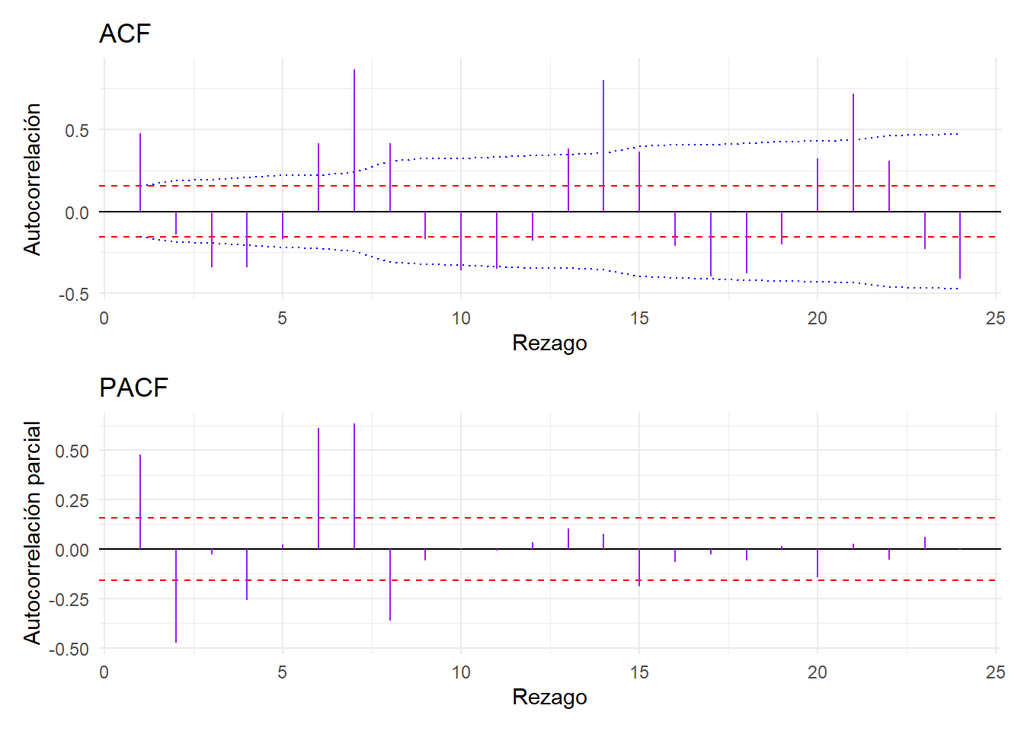

```r
diagnostico_tendencia_lineal3$correlograma$grafico
```

En las gráficas se observa que los errores presentan picos significativos que superan los límites permitidos, destacando patrones repetitivos y altos en los rezagos 7, 14 y 21. Esto indica claramente que los residuos tienen un fuerte componente estacional o periódico que el modelo de tendencia lineal no logró capturar. En consecuencia, los errores no se comportan como ruido blanco.

Ljung Box

**Mostrar/ocultar código**

```r
cat(
  "Estadístico de prueba:", round(
    diagnostico_tendencia_lineal3$ljung_box$estadistico, 4
  ), "\n",
  "Grados de libertad:", diagnostico_tendencia_lineal3$ljung_box$grados_libertad, "\n",
  "Valor crítico:", round(
    diagnostico_tendencia_lineal3$ljung_box$valor_critico, 4
  ), "\n",
  "Valor p:", round(
    diagnostico_tendencia_lineal3$ljung_box$valor_p, 4
  ), "\n"
)
```

```
Estadístico de prueba: 717.9336
 Grados de libertad: 24
 Valor crítico: 36.415
 Valor p: 0
```

En la prueba de Ljung-Box se obtiene un valor p cercano a cero. Por tanto, se rechaza la hipótesis nula de ausencia de autocorrelación en los errores. Esto indica que los errores de la tendencia lineal presentan dependencia temporal y que el modelo no captura completamente la dinámica de las ventas diarias.

Jarque Bera

**Mostrar/ocultar código**

```r
cat(
  "Estadístico de prueba:", round(
    diagnostico_tendencia_lineal3$jarque_bera$estadistico, 4
  ), "\n",
  "Grados de libertad:", diagnostico_tendencia_lineal3$jarque_bera$grados_libertad, "\n",
  "Valor crítico:", round(
    diagnostico_tendencia_lineal3$jarque_bera$valor_critico, 4
  ), "\n",
  "Valor p:", format.pval(
    diagnostico_tendencia_lineal3$jarque_bera$valor_p,
    digits = 4
  ), "\n"
)
```

```
Estadístico de prueba: 10.7202
 Grados de libertad: 2
 Valor crítico: 5.9915
 Valor p: 0.0047
```

La prueba de Jarque-Bera presenta un valor p de 0.0047. Por tanto, se rechaza la hipótesis nula de normalidad, lo que indica que los errores del modelo de tendencia lineal no siguen una distribución normal.

Durbin Watson

**Mostrar/ocultar código**

```r
diagnostico_tendencia_lineal3$durbin_watson <-
  durbin_watson(modelo_tendencia3$parametros$residuos)

cat(
  "Estadístico de prueba:",
  round(diagnostico_tendencia_lineal3$durbin_watson$estadistico, 4), "\n",
  "d aprox:",
  round(diagnostico_tendencia_lineal3$durbin_watson$d_aprox, 4), "\n",
  "dL:",
  round(diagnostico_tendencia_lineal3$durbin_watson$dL, 4), "\n",
  "dU:",
  round(diagnostico_tendencia_lineal3$durbin_watson$dU, 4), "\n"
)
```

```
Estadístico de prueba: 1.0417
 d aprox: 1.045
 dL: 1.6765
 dU: 1.7086
```

El valor de la prueba de Durbin-Watson (aproximadamente 1.05) se encuentra por debajo del límite inferior ($1.68$), lo que indica que existe una clara autocorrelación positiva en los errores del modelo. Esto significa que los errores no son independientes entre sí y están relacionados a lo largo del tiempo, lo que confirma que el modelo de tendencia lineal actual no logró capturar toda la información importante de la serie.

#### 5.1.3 Medidas de error

**Mostrar/ocultar código**

```r
# Evaluacion de los metodos
eval_s3_media     <- origen_movil(serie3$y, fn_ajuste = ajustar_media, H = 7, n_eval = 40, s = 7)

eval_s3_ing_est   <- origen_movil(serie3$y, fn_ajuste = ajustar_ingenuo_estacional, H = 7, n_eval = 40, s = 7)

eval_s3_mm        <- origen_movil(serie3$y, fn_ajuste = ajustar_mm, H = 7, n_eval = 40, s = 7, k = resultado_opt_3$optimo$k)

eval_s3_ses       <- origen_movil(serie3$y, fn_ajuste = ajustar_ses, H = 7, n_eval = 40, s = 7, alpha =
                                    resultado_opt_ses3$optimo$alpha)

eval_s3_tend_est  <- origen_movil(serie3$y, fn_ajuste = ajustar_tendencia_estacional, H = 7, n_eval = 40, s = 7)

eval_s3_hw_add <- origen_movil(
  serie3$y,
  fn_ajuste = ajustar_hw,
  H = 7,
  n_eval = 40,
  s = 7,
  alpha = opt_holt_ad$optimo$alpha,
  beta  = opt_holt_ad$optimo$beta,
  gamma = opt_holt_ad$optimo$gamma
)

eval_s3_hw_mult <- origen_movil(
  serie3$y,
  fn_ajuste = ajustar_hw_mult,
  H = 7,
  n_eval = 40,
  s = 7,
  alpha = opt_holt_ad$optimo$alpha,
  beta  = opt_holt_ad$optimo$beta,
  gamma = opt_holt_ad$optimo$gamma
)

eval_s3_lin_con   <- origen_movil(serie3$y, fn_ajuste = ajustar_tendencia, H = 7, n_eval = 40, s = 7, tipo = "lineal")
```

**Mostrar/ocultar código**

```r
# Errores para h = 1
tabla_s3_h1 <- tibble(
  `Método de Pronóstico` = c(
    "Media Simple",
    "Referente Ingenuo Estacional (s=7)",
    "Media Móvil (MM)",
    "Suavización Exponencial Simple (SES)",
    "Tendencia Estacional (Ficticias)",
    "Holt-Winters Aditivo",
    "Holt-Winters Multiplicativo",
    "Contraste: Tendencia Lineal MCO"
  ),
  RMSE = c(
    eval_s3_media$h1$RMSE,
    eval_s3_ing_est$h1$RMSE,
    eval_s3_mm$h1$RMSE,
    eval_s3_ses$h1$RMSE,
    eval_s3_tend_est$h1$RMSE,
    eval_s3_hw_add$h1$RMSE,
    eval_s3_hw_mult$h1$RMSE,
    eval_s3_lin_con$h1$RMSE
  ),
  MAD = c(
    eval_s3_media$h1$MAD,
    eval_s3_ing_est$h1$MAD,
    eval_s3_mm$h1$MAD,
    eval_s3_ses$h1$MAD,
    eval_s3_tend_est$h1$MAD,
    eval_s3_hw_add$h1$MAD,
    eval_s3_hw_mult$h1$MAD,
    eval_s3_lin_con$h1$MAD
  ),
  `MAPE (%)` = c(
    eval_s3_media$h1$MAPE,
    eval_s3_ing_est$h1$MAPE,
    eval_s3_mm$h1$MAPE,
    eval_s3_ses$h1$MAPE,
    eval_s3_tend_est$h1$MAPE,
    eval_s3_hw_add$h1$MAPE,
    eval_s3_hw_mult$h1$MAPE,
    eval_s3_lin_con$h1$MAPE
  )
) %>%
  arrange(RMSE) %>%
  mutate(
    RMSE = round(RMSE, 3),
    MAD  = round(MAD, 3),
    `MAPE (%)` = round(`MAPE (%)`, 3)
  )

kable(
  tabla_s3_h1,
  align = "lccc",
  caption = "Serie 3: Medidas de error para horizonte h = 1 (Origen Móvil)",
  booktabs = TRUE
)
```

Serie 3: Medidas de error para horizonte h = 1 (Origen Móvil)

| Método de Pronóstico | RMSE | MAD | MAPE (%) |
| --- | --- | --- | --- |
| Holt-Winters Aditivo | 11.178 | 9.234 | 2.167 |
| Holt-Winters Multiplicativo | 11.441 | 9.414 | 2.213 |
| Tendencia Estacional (Ficticias) | 13.189 | 10.709 | 2.486 |
| Referente Ingenuo Estacional (s=7) | 13.489 | 10.510 | 2.487 |
| Media Móvil (MM) | 30.446 | 24.785 | 5.624 |
| Contraste: Tendencia Lineal MCO | 33.143 | 25.765 | 5.767 |
| Suavización Exponencial Simple (SES) | 33.641 | 27.389 | 6.204 |
| Media Simple | 42.141 | 30.692 | 6.706 |

Después se encuentran la Tendencia Estacional con Variables Ficticias (MAPE del $2.49\%$ y MAD de $10.71$) y el Referente Ingenuo Estacional ($s=7$), con un MAPE del $2.49\%$ y una MAD de $10.51$. Ambos métodos ofrecen resultados competitivos, lo que resalta la importancia de considerar el patrón semanal de la serie. En particular, el Referente Ingenuo Estacional utiliza como pronóstico el valor observado siete periodos atrás, aprovechando la repetición de este patrón.

**Mostrar/ocultar código**

```r
# Errores para h = 7
tabla_s3_h7 <- tibble(
  `Método de Pronóstico` = c(
    "Media Simple",
    "Referente Ingenuo Estacional (s=7)",
    "Media Móvil (MM)",
    "Suavización Exponencial Simple (SES)",
    "Tendencia Estacional (Ficticias)",
    "Holt-Winters Aditivo",
    "Holt-Winters Multiplicativo",
    "Contraste: Tendencia Lineal MCO"
  ),
  RMSE = c(
    eval_s3_media$hH$RMSE,
    eval_s3_ing_est$hH$RMSE,
    eval_s3_mm$hH$RMSE,
    eval_s3_ses$hH$RMSE,
    eval_s3_tend_est$hH$RMSE,
    eval_s3_hw_add$hH$RMSE,
    eval_s3_hw_mult$hH$RMSE,
    eval_s3_lin_con$hH$RMSE
  ),
  MAD = c(
    eval_s3_media$hH$MAD,
    eval_s3_ing_est$hH$MAD,
    eval_s3_mm$hH$MAD,
    eval_s3_ses$hH$MAD,
    eval_s3_tend_est$hH$MAD,
    eval_s3_hw_add$hH$MAD,
    eval_s3_hw_mult$hH$MAD,
    eval_s3_lin_con$hH$MAD
  ),
  `MAPE (%)` = c(
    eval_s3_media$hH$MAPE,
    eval_s3_ing_est$hH$MAPE,
    eval_s3_mm$hH$MAPE,
    eval_s3_ses$hH$MAPE,
    eval_s3_tend_est$hH$MAPE,
    eval_s3_hw_add$hH$MAPE,
    eval_s3_hw_mult$hH$MAPE,
    eval_s3_lin_con$hH$MAPE
  )
) %>%
  arrange(RMSE) %>%
  mutate(
    RMSE = round(RMSE, 3),
    MAD  = round(MAD, 3),
    `MAPE (%)` = round(`MAPE (%)`, 3)
  )

kable(
  tabla_s3_h7,
  align = "lccc",
  caption = "Serie 3: Medidas de error para horizonte h = 7 (Origen Móvil)",
  booktabs = TRUE
)
```

Serie 3: Medidas de error para horizonte h = 7 (Origen Móvil)

| Método de Pronóstico | RMSE | MAD | MAPE (%) |
| --- | --- | --- | --- |
| Referente Ingenuo Estacional (s=7) | 11.938 | 9.545 | 2.239 |
| Tendencia Estacional (Ficticias) | 12.749 | 10.115 | 2.338 |
| Holt-Winters Aditivo | 14.096 | 10.731 | 2.533 |
| Holt-Winters Multiplicativo | 14.214 | 10.848 | 2.556 |
| Media Móvil (MM) | 27.902 | 21.967 | 4.955 |
| Suavización Exponencial Simple (SES) | 29.469 | 23.089 | 5.190 |
| Contraste: Tendencia Lineal MCO | 31.752 | 24.082 | 5.368 |
| Media Simple | 42.361 | 31.098 | 6.790 |

#### 5.1.4 Validar Ganador

El método Holt Winters Aditivo presenta los menores errores para el horizonte de un paso ($h=1$), por lo que se selecciona como ganador para este horizonte.

**Gráfico**

**Mostrar/ocultar código**

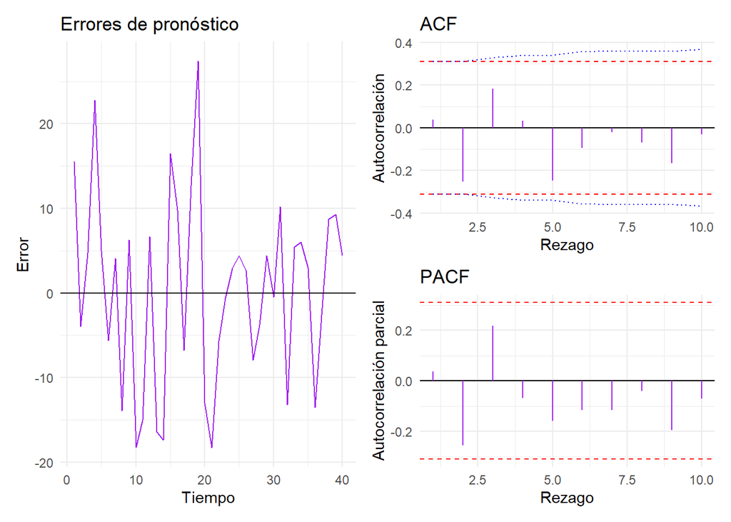

```r
g1_s3 <- resultado_errores_hw_ad$grafico_errores
g2_s3 <- resultado_errores_hw_ad$correlograma$grafico

g1_s3 | g2_s3
```

En la gráfica se observa que los errores de pronóstico fluctúan alrededor de la línea cero de forma relativamente aleatoria, sin mostrar una tendencia marcada o patrones sistemáticos a lo largo del tiempo.

En el ACF y PACF, no hay ninguna autocorrelación significativa entre los errores del modelo.Los errores se comportan como ruido blanco.

**Prueba t**

Prueba de Hipótesis

$$H_0: \mu_e = 0$$
$$H_1: \mu_e \neq 0$$

Estadístico de Prueba:

$$t = \frac{\bar{e}}{s_e / \sqrt{40}}$$

Distribución bajo $H_0$

$$t \sim t_{39}$$

Región de Rechazo

$$|t| > t_{0.975,\,39}$$

**Mostrar/ocultar código**

```r
cat(
  "Estadístico de prueba:", round(resultado_errores_hw_ad$t, 4), "\n",
  "Grados de libertad:", resultado_errores_hw_ad$grados_libertad_t, "\n",
  "Valor crítico:", round(
    qt(0.975, resultado_errores_hw_ad$grados_libertad_t), 4
  ), "\n",
  "Valor p:", round(resultado_errores_hw_ad$valor_p_t, 4), "\n"
)
```

```
Estadístico de prueba: 0.2349
 Grados de libertad: 39
 Valor crítico: 2.0227
 Valor p: 0.8155
```

Como el valor p es mayor a 0.05, no se rechaza $H_0$. Por lo tanto, el modelo de Holt-Winters aditivo no presenta sesgos sistemáticos.

**Ljung Box**

Prueba de Hipótesis

Estadístico de Prueba

Distribución

Región de Rechazo

**Mostrar/ocultar código**

```r
cat(
  "Estadístico de prueba:", round(
    resultado_errores_hw_ad$ljung_box$estadistico, 4
  ), "\n",
  "Grados de libertad:", resultado_errores_hw_ad$ljung_box$grados_libertad, "\n",
  "Valor crítico:", round(
    resultado_errores_hw_ad$ljung_box$valor_critico, 4
  ), "\n",
  "Valor p:", round(
    resultado_errores_hw_ad$ljung_box$valor_p, 4
  ), "\n"
)
```

```
Estadístico de prueba: 9.6309
 Grados de libertad: 10
 Valor crítico: 18.307
 Valor p: 0.4735
```

Como el valor p es mayor a 0.05, no se rechaza $H_0$. Los errores no están autocorrelacionados y se comportan como ruido blanco.

**Jarque Bera**

Prueba de Hipótesis

$$H_0:\text{los errores tienen distribución normal}$$
$$H_1:\text{los errores no tienen distribución normal}$$

Distribución Bajo $H_0$:

$$JB \sim \chi^2_{2}$$

Estadístico de Prueba

$$JB = \frac{T}{6} \left( A^2 + \frac{(K - 3)^2}{4} \right)$$

Región de rechazo

$$JB>\chi^2_{0.95,2}$$

**Mostrar/ocultar código**

```r
cat(
  "Estadístico de prueba:", round(
    resultado_errores_hw_ad$jarque_bera$estadistico, 4
  ), "\n",
  "Grados de libertad:", resultado_errores_hw_ad$jarque_bera$grados_libertad, "\n",
  "Valor crítico:", round(
    resultado_errores_hw_ad$jarque_bera$valor_critico, 4
  ), "\n",
  "Valor p:", format.pval(
    resultado_errores_hw_ad$jarque_bera$valor_p,
    digits = 4
  ), "\n"
)
```

```
Estadístico de prueba: 0.3794
 Grados de libertad: 2
 Valor crítico: 5.9915
 Valor p: 0.8272
```

Como el valor p es mayor a 0.05, no se rechaza $H_0$: no hay evidencia estadística suficiente para afirmar que los errores se aparten de una distribución normal.

**Durbin Watson**

Prueba de Hipótesis:

$$H_0:\rho=0$$
$$H_1:\rho\neq0$$

Estadístico de Prueba:

$$DW=\frac{\sum_{t=2}^{T}(e_t-e_{t-1})^2} {\sum_{t=1}^{T}e_t^2}$$

**Mostrar/ocultar código**

```r
cat(
  "Estadístico de prueba:",
  round(resultado_errores_hw_ad$durbin_watson$estadistico, 4), "\n",
  "d aprox:",
  round(resultado_errores_hw_ad$durbin_watson$d_aprox, 4), "\n",
  "dL:",
  round(resultado_errores_hw_ad$durbin_watson$dL, 4), "\n",
  "dU:",
  round(resultado_errores_hw_ad$durbin_watson$dU, 4), "\n"
)
```

```
Estadístico de prueba: 1.8731
 d aprox: 1.9247
 dL: 1.3427
 dU: 1.4677
```

Como el valor de la prueba de Durbin-Watson (cercano a 1.88) es mayor que el límite superior (1.47), se encuentra en la zona de no autocorrelación. Por tanto, no hay evidencia de autocorrelación de primer orden en los errores del modelo de Holt-Winters aditivo.

#### 5.1.5 Pronóstico Final

**Mostrar/ocultar código**

```r
T_3 <- length(serie3$y)
H_3 <- 7
```

**Mostrar/ocultar código**

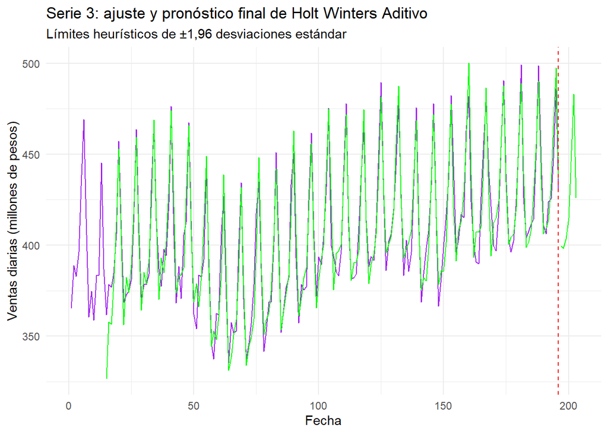

```r
# Ajustar Holt-Winters aditivo usando toda la serie 3
modelo_final_3 <- ajustar_hw(
  serie3$y,
  s = 7,
  alpha = alpha_opt_ad,
  beta = beta_opt_ad,
  gamma = gamma_opt_ad
)

# Pronósticos de los H días siguientes
pronosticos_finales_3 <- modelo_final_3$pronosticar(H_3)

# Desviación estándar de los errores para cada horizonte
desv_errores_3 <- sapply(1:7, function(h) {
  errores <- eval_s3_hw_add$todos$error[
    eval_s3_hw_add$todos$h == h
  ]
  sd(errores)
})

# Datos para el gráfico
grafico_final_3 <- data.frame(
  tiempo = 1:(T_3 + H_3),
  real = c(serie3$y, rep(NA, H_3)),
  ajuste = c(
    modelo_final_3$yhat,
    rep(NA, H_3)
  ),
  pronostico = c(
    rep(NA, T_3),
    pronosticos_finales_3
  ),
  inferior = c(
    rep(NA, T_3),
    pronosticos_finales_3 - 1.96 * desv_errores_3
  ),
  superior = c(
    rep(NA, T_3),
    pronosticos_finales_3 + 1.96 * desv_errores_3
  )
)

# Gráfico final
ggplot2::ggplot(
  grafico_final_3,
  ggplot2::aes(x = tiempo)
) +
  ggplot2::geom_line(
    ggplot2::aes(y = real),
    color = "purple"
  ) +
  ggplot2::geom_line(
    ggplot2::aes(y = ajuste),
    color = "green"
  ) +
  ggplot2::geom_line(
    ggplot2::aes(y = pronostico),
    color = "green"
  ) +
  ggplot2::geom_line(
    ggplot2::aes(y = inferior),
    color = "black",
    linetype = "dotted"
  ) +
  ggplot2::geom_line(
    ggplot2::aes(y = superior),
    color = "black",
    linetype = "dotted"
  ) +
  ggplot2::geom_vline(
    xintercept = T_3,
    color = "red",
    linetype = "dashed"
  ) +
  ggplot2::labs(
    title = "Serie 3: ajuste y pronóstico final de Holt Winters Aditivo",
    subtitle = "Límites heurísticos de ±1,96 desviaciones estándar",
    x = "Fecha",
    y = "Ventas diarias (millones de pesos)"
  ) +
  ggplot2::theme_minimal()
```

En la gráfica se observa que la línea verde de estimación sigue de manera muy cercana el comportamiento de la serie original, lo que demuestra que el modelo logró capturar con gran precisión tanto los altibajos estacionales como la tendencia creciente a lo largo de los días. El modelo proyecta el pronóstico futuro manteniendo ese mismo patrón cíclico

**Mostrar/ocultar código**

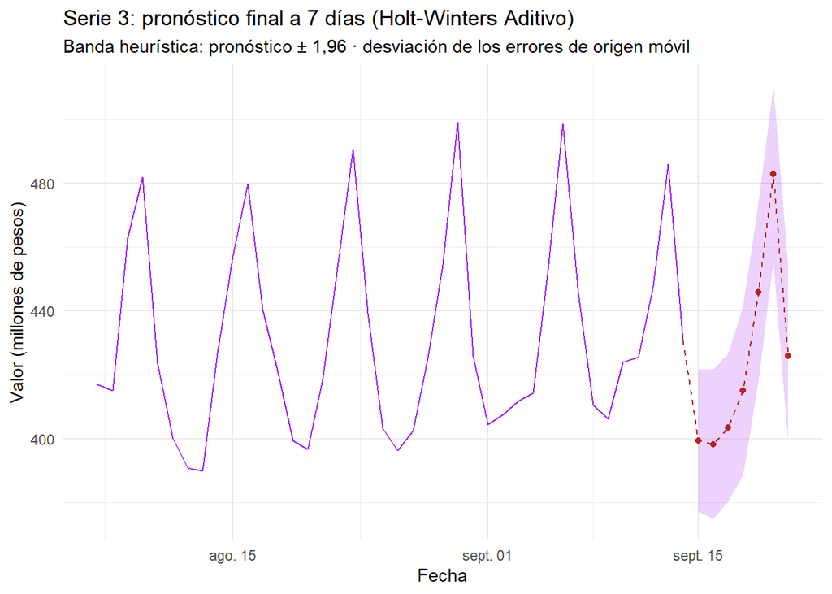

```r
# Ultimo tramo
ganador_s3 <- "Holt-Winters Aditivo"

# Se elimina el parámetro 'tipo = "aditivo"' que no existe en ajustar_hw()
fn_s3 <- function(y) {
  ajustar_hw(
    y,
    s = 7,
    alpha = opt_holt_ad$optimo$alpha,
    beta  = opt_holt_ad$optimo$beta,
    gamma = opt_holt_ad$optimo$gamma
  )
}

final_s3 <- pronostico_final(
  y = serie3$y,
  fechas = serie3$fecha,
  fn = fn_s3,
  H = 7,
  n_eval = 40,
  paso = 1,
  titulo = paste0("Serie 3: pronóstico final a 7 días (", ganador_s3, ")"),
  unidad = attr(serie3, "unidad")
)

final_s3$grafico
```

**Mostrar/ocultar código**

```r
tabla_final(final_s3, "Serie 3: Pronóstico final y banda heurística")
```

Serie 3: Pronóstico final y banda heurística

| h | Fecha | Pronóstico | Desv. errores (s_h) | Límite inferior | Límite superior |
| --- | --- | --- | --- | --- | --- |
| 1 | 2025-09-15 | 399.43 | 11.31 | 377.26 | 421.61 |
| 2 | 2025-09-16 | 398.19 | 11.92 | 374.83 | 421.55 |
| 3 | 2025-09-17 | 403.51 | 11.86 | 380.26 | 426.76 |
| 4 | 2025-09-18 | 414.95 | 13.50 | 388.49 | 441.42 |
| 5 | 2025-09-19 | 445.93 | 14.27 | 417.97 | 473.89 |
| 6 | 2025-09-20 | 482.99 | 13.97 | 455.60 | 510.38 |
| 7 | 2025-09-21 | 425.96 | 14.13 | 398.26 | 453.66 |

El método ganador a un paso $(h = 1)$ para la Serie 3 es **Holt-Winters Aditivo**. Reajustado con las 196 observaciones, pronostica para los próximos 7 días valores entre 398.2 y 483 millones de pesos. La banda se ensancha con el horizonte porque los errores de origen móvil crecen al pronosticar más pasos adelante; al ser heurística, debe leerse como un orden de magnitud de la incertidumbre y no como una probabilidad exacta.

#### 5.1.6 Conclusión

Como la serie termina el domingo 14 de septiembre, el pronóstico de la próxima semana va de lunes a domingo (en millones de pesos):

- *Lunes:* $399.43$
- *Martes:* $398.19$
- *Miércoles:* $403.51$
- *Jueves:* $414.95$
- *Viernes:* $445.93$
- *Sábado:* $482.99$
- *Domingo:* $425.96$.

## 6 Argumentos para los interesados

**Mapa de interesados**

| Serie | Interesados (roles) | Decisión concreta | Costo del error por exceso (sobreestimar) | Costo del error por defecto (subestimar) |
| --- | --- | --- | --- | --- |
| *Serie 1* | • *Decisión:* Gerencia de Administración y Mercadeo • *Ejecución:* Equipo de compras e inventario • *Afectados:* Finanzas (promoción de 45 millones) | Decidir si se invierten *45 millones de pesos* en la promoción del lunes, según si el valor promedio de la compra quedará por debajo de la meta de *510 mil COP*. | Gastar 45 millones en publicidad cuando la demanda ya era suficiente sin promoción. | Perder clientes y volumen de compras por no estimular el mercado en un momento de baja demanda. |
| *Serie 2* | • *Decisión:* Equipo de Infraestructura y Plataforma • *Ejecución:* Área de tecnología / Compras IT • *Afectados:* Usuarios registrados de la tienda en línea | Decidir cuándo adquirir un nuevo bloque de *5.000 clientes* (la capacidad licenciada es de *45.000*). | Pagar por anticipado una licencia que todavía no se necesita. | Caída del sistema o rechazo de nuevos registros al superar el tope de 45.000 clientes. |
| *Serie 3* | • *Decisión:* Encargado de compras e inventario • *Ejecución:* Proveedores de perecederos y personal de tienda • *Afectados:* Clientes del supermercado | Definir las cantidades de frutas, verduras y panadería que se piden con *2 días de anticipación* para cada día de la semana. | Pérdida por desperdicio y merma de alimentos perecederos no vendidos. | Venta perdida por desabastecimiento y pérdida de clientes habituales. |

**El argumento de la recomendación**

**Serie 1 (Modelo Ganador: Holt Lineal)**

[output not shown]

**Serie 2 (Modelo Ganador: Holt Lineal)**

[output not shown]

**Serie 3 (Modelo Ganador: Holt-Winters Aditivo)**

[output not shown]

## Referencias

«Demostración matemática del Punto 4(d)». 2024. Documento complementario de soporte, Universidad Nacional de Colombia Sede Medellín. https://drive.google.com/file/d/1TGggjd3YvEupV_BpD9a6BVraGvgwbWLs/view?usp=drive_link.